# Project 2: Data Mining, Classification, Prediction

SDS322E

# Mining, Classification, Prediction

## Anne Siri Snell, as223795

### Introduction

My data is from the FiveThirtyEight data package already built into R. The specific dataset i the ‘hatecrimes’ dataset, which contains data on the number of hate crimes on the state level along with id variable for the state and 9 different demographic variables. The variables of my interest are number of hate crimes, income, share of non-white population, share of population living in metropolitan areas and a binary variable I’ve created that indicated whether or not the state is above or below the mean share of adult population with a high school degree.

Income is measured as annual median household income in 2016, share of non-white population is share of the population that is not white in 2015 and ranges from 0-1, number of hate crimes is measured as per 100,000 population in 2016, share of the population that lives in metropolitan areas is measured in 2015 and ranges from 0-1. These are all numeric variables.

My binary variable ‘highschool’ is given a 0 if the state have a share of population with a high school degree below the mean and 1 if the state have a population with a high school degree above the mean.

```r
# Load packages
library(tidyverse)
library(fivethirtyeight)
library(cluster)
library(dplyr)
library(ggplot2)

# Show dataframe
print(hate_crimes)
```

```
## # A tibble: 51 x 13
##    state          state_abbrev median_house_inc share_unemp_seas share_pop_metro
##    <chr>          <chr>                   <int>            <dbl>           <dbl>
##  1 Alabama        AL                      42278            0.06             0.64
##  2 Alaska         AK                      67629            0.064            0.63
##  3 Arizona        AZ                      49254            0.063            0.9
##  4 Arkansas       AR                      44922            0.052            0.69
##  5 California     CA                      60487            0.059            0.97
##  6 Colorado       CO                      60940            0.04             0.8
##  7 Connecticut    CT                      70161            0.052            0.94
##  8 Delaware       DE                      57522            0.049            0.9
##  9 District of C… DC                      68277            0.067            1
## 10 Florida        FL                      46140            0.052            0.96
## # … with 41 more rows, and 8 more variables: share_pop_hs <dbl>,
## #   share_non_citizen <dbl>, share_white_poverty <dbl>, gini_index <dbl>,
## #   share_non_white <dbl>, share_vote_trump <dbl>,
## #   hate_crimes_per_100k_splc <dbl>, avg_hatecrimes_per_100k_fbi <dbl>
```

```r
# Count number of observations
length(as.matrix(hate_crimes))
```

```
## [1] 663
```

```r
# Create new binary varible 'highschool'
mean(hate_crimes$share_pop_hs)
```

```
## [1] 0.8691176
```

```r
hate_crimes$highschool <- ifelse(hate_crimes$share_pop_hs > 0.8691176,
    1, 0)

# Show number of observations in each category of
# 'highschool'
table(hate_crimes$highschool)
```

```
##
##  0  1
## 23 28
```

### Cluster Analysis

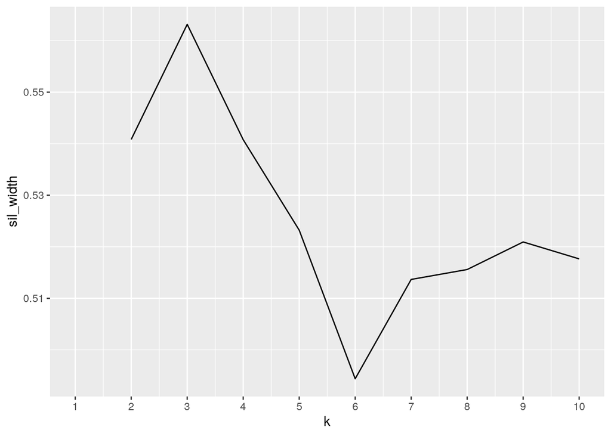

```r
# Choosing number of clusters
pam_dat <- hate_crimes %>% select(median_house_inc, share_non_white,
    share_pop_metro)
sil_width <- vector()
for (i in 2:10) {
    pam_fit <- pam(pam_dat, k = i)
    sil_width[i] <- pam_fit$silinfo$avg.width
}
ggplot() + geom_line(aes(x = 1:10, y = sil_width)) + scale_x_continuous(name = "k",
    breaks = 1:10)
```

From the above plot I suggest to choose three clusters.

```r
# Running cluster analysis
pam1 <- pam_dat %>% pam(k = 3)  #use the pam function
pam1
```

```
## Medoids:
##      ID median_house_inc share_non_white share_pop_metro
## [1,] 10            46140            0.46            0.96
## [2,]  2            67629            0.42            0.63
## [3,] 26            56630            0.20            0.78
## Clustering vector:
##  [1] 1 2 1 1 3 3 2 3 2 1 1 2 3 3 1 3 3 1 1 3 2 2 3 2 1 3 1 3 1 2 2 1 3 1 3 1 1 3
## [39] 3 3 1 3 1 3 2 3 2 3 1 3 3
## Objective function:
##    build     swap
## 2936.804 2851.667
##
## Available components:
##  [1] "medoids"    "id.med"     "clustering" "objective"  "isolation"
##  [6] "clusinfo"   "silinfo"    "diss"       "call"       "data"
```

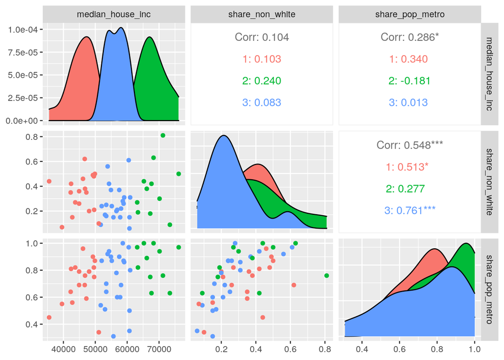

```r
# Saving clusters to dataframe
hate_crimes <- hate_crimes %>% mutate(cluster = as.factor(pam1$clustering))

# Visualizing clusters
library(GGally)
ggpairs(hate_crimes, columns = c("median_house_inc", "share_non_white",
    "share_pop_metro"), aes(color = cluster))
```

```r
# Calculating average silhouette width
pam1$silinfo$avg.width
```

```
## [1] 0.5631555
```

As the average silhouette width is between 0.51−0.70 a reasonable structure have been found.

### Dimensionality Reduction with PCA

```r
# PCA
hate_crimes_nums <- hate_crimes %>% select(median_house_inc,
    share_non_white, share_pop_metro) %>% scale
hate_crimes_pca <- princomp(hate_crimes_nums)
summary(hate_crimes_pca, loadings = T)
```

```
## Importance of components:
##                           Comp.1    Comp.2    Comp.3
## Standard deviation     1.2775067 0.9474225 0.6415167
## Proportion of Variance 0.5548879 0.3051872 0.1399249
## Cumulative Proportion  0.5548879 0.8600751 1.0000000
##
## Loadings:
##                  Comp.1 Comp.2 Comp.3
## median_house_inc  0.390  0.888  0.244
## share_non_white   0.621 -0.449  0.642
## share_pop_metro   0.680        -0.727
```

```r
eigval <- hate_crimes_pca$sdev^2
varprop = round(eigval/sum(eigval), 2)
round(cumsum(eigval)/sum(eigval), 2)  #cumulative proportion of variance
```

```
## Comp.1 Comp.2 Comp.3
##   0.55   0.86   1.00
```

```r
eigval  #eigenvalues
```

```
##    Comp.1    Comp.2    Comp.3
## 1.6320234 0.8976094 0.4115437
```

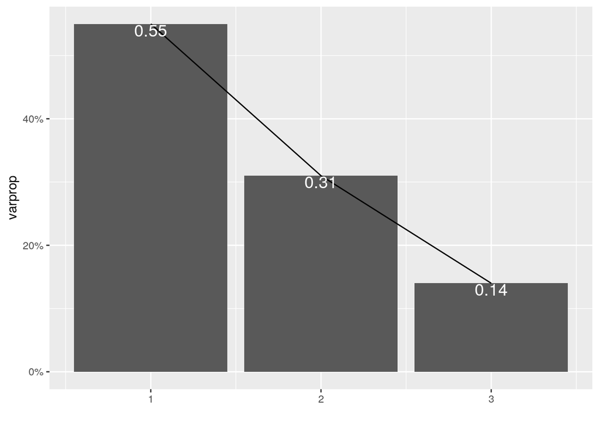

```r
ggplot() + geom_bar(aes(y = varprop, x = 1:3), stat = "identity") +
    xlab("") + geom_path(aes(y = varprop, x = 1:3)) + geom_text(aes(x = 1:3,
    y = varprop, label = round(varprop, 2)), vjust = 1, col = "white",
    size = 5) + scale_y_continuous(breaks = seq(0, 0.6, 0.2),
    labels = scales::percent) + scale_x_continuous(breaks = 1:10)
```

There are several rules of thumb to chose the right number of PCs. One is to look at when the scree plot flattens, but it isn’t really clear from my plot when it flattens. Another startegy is to pick the number of PCs until cumulative proportion of variance is >80%. This would make me chose 2 PCs. A third rule is to pick PCs whose eigenvalues are greater than 1 (Kaiser’s rule). This rule woudl make me choose only the first PC. All combined I choose PC1 and PC2, which explains 86 % of the variance in my data. PC1 shows positive and relatively high loadings on both income, share of non-white population and share of population in metropolitan areas. This means that the higher score on PC1, the higher overall score on the included variables. PC2 shows that higher scores on PC2 mean high median household income but low score on share of non-white population.

### Linear Classifier

```r
# Replacing NAs with 0
hate_crimes[is.na(hate_crimes)] <- 0

# Logistic regression as linear classifier
fit <- glm(highschool ~ median_house_inc + share_non_white +
    share_pop_metro + hate_crimes_per_100k_splc, data = hate_crimes,
    family = "binomial")

score <- predict(fit, type = "response")

class_diag(score, truth = hate_crimes$highschool, positive = 1)
```

```
##           acc   sens  spec    ppv     f1    ba    auc
## Metrics 0.902 0.8929 0.913 0.9259 0.9091 0.903 0.9612
```

With an AUC of 0.96 the model is doing great!

```r
# Cross validation

k = 5
data <- hate_crimes[sample(nrow(hate_crimes)), ]  #randomly order rows
folds <- cut(seq(1:nrow(data)), breaks = k, labels = F)  #create folds
diags <- NULL
for (i in 1:k) {
    ## Create training and test sets
    train <- data[folds != i, ]
    test <- data[folds == i, ]
    truth <- test$highschool
    ## Train model on training set
    fit <- glm(highschool ~ median_house_inc + share_non_white +
        share_pop_metro + hate_crimes_per_100k_splc, data = train,
        family = "binomial")
    probs <- predict(fit, newdata = test, type = "response")
    ## Test model on test set (save all k results)
    diags <- rbind(diags, class_diag(probs, truth, positive = 1))
}

summarize_all(diags, mean)
```

```
##       acc    sens    spec     ppv      f1      ba     auc
## 1 0.84546 0.82428 0.86668 0.90476 0.85496 0.84546 0.93142
```

### Non-Parametric Classifier

```r
# Fit of non-parametric classifier - k-nearest neighbors

library(caret)
knn_fit <- knn3(factor(highschool == 1, levels = c("TRUE", "FALSE")) ~
    median_house_inc + share_non_white + share_pop_metro + hate_crimes_per_100k_splc,
    data = hate_crimes, k = 5)
y_hat_knn <- predict(knn_fit, hate_crimes)

table(truth = factor(hate_crimes$highschool == 1, levels = c("TRUE",
    "FALSE")), prediction = factor(y_hat_knn[, 1] > 0.5, levels = c("TRUE",
    "FALSE")))
```

```
##        prediction
## truth   TRUE FALSE
##   TRUE    26     2
##   FALSE    5    18
```

```r
class_diag(y_hat_knn[, 1], hate_crimes$highschool, positive = 1)
```

```
##            acc   sens   spec    ppv     f1     ba    auc
## Metrics 0.8627 0.9286 0.7826 0.8387 0.8814 0.8556 0.9123
```

With an AUC of 0.91 the model is doing great!

```r
# Cross validation

k = 5  #choose number of folds
data <- hate_crimes[sample(nrow(hate_crimes)), ]  #randomly order rows
folds <- cut(seq(1:nrow(hate_crimes)), breaks = k, labels = F)  #create 10 folds
diags <- NULL
for (i in 1:k) {
    ## Create training and test sets
    train <- data[folds != i, ]
    test <- data[folds == i, ]
    truth <- test$highschool
    ## Train model on training set
    fit <- knn3(highschool ~ median_house_inc + share_non_white +
        share_pop_metro + hate_crimes_per_100k_splc, data = train)
    probs <- predict(fit, newdata = test)[, 2]
    ## Test model on test set
    diags <- rbind(diags, class_diag(probs, truth, positive = 1))
}

summarize_all(diags, mean)
```

```
##       acc sens    spec    ppv    f1      ba     auc
## 1 0.80182  0.9 0.64166 0.7889 0.833 0.77084 0.78214
```

### Regression/Numeric Prediction

```r
# Fit of linear regression model
fit <- lm(mpg ~ ., data = mtcars)  #predict mpg from all other variables
yhat <- predict(fit)  #predicted mpg

mean((mtcars$mpg - yhat)^2)  #mean squared error (MSE)
```

```
## [1] 4.609201
```

```r
# Cross validation

k = 5  #choose number of folds
data <- hate_crimes[sample(nrow(hate_crimes)), ]  #randomly order rows
folds <- cut(seq(1:nrow(hate_crimes)), breaks = k, labels = F)  #create folds
diags <- NULL
for (i in 1:k) {
    train <- data[folds != i, ]
    test <- data[folds == i, ]
    ## Fit linear regression model to training set
    fit <- lm(highschool ~ median_house_inc + share_non_white +
        share_pop_metro + hate_crimes_per_100k_splc, data = train)
    ## Get predictions/y-hats on test set (fold i)
    yhat <- predict(fit, newdata = test)
    ## Compute prediction error (MSE) for fold i
    diags <- mean((test$highschool - yhat)^2)
}
mean(diags)  ## Get average MSE across all folds
```

```
## [1] 0.0764382
```

### Python

```r
library(reticulate)

monthly_income <- hate_crimes$median_house_inc/12
```

```python
print(r.monthly_income)
```

```
## [3523.1666666666665, 5635.75, 4104.5, 3743.5, 5040.583333333333, 5078.333333333333, 5846.75, 4793.5, 5689.75, 3845.0, 4129.583333333333, 5935.25, 4453.166666666667, 4576.333333333333, 4005.0, 4817.5, 4453.666666666667, 3565.5, 3533.8333333333335, 4309.166666666667, 6347.083333333333, 5262.5833333…
```

For the sharing of objects between R and Python, I created a new variable in an R chunck that gives the median monthly house income in every state and then I used an Python chunck to print out the values of the new variable.